# Chapter 7 - LME analysis of h_f0 ~ Mode and Nuclear pitch accents:

Antoin Rodgers

5.6.2022

The aims of this set of analyses is to see if, once we account for assumed speaker-motivated use of pitch accent, the apparent “paralinguistic” differences in scaling (and possibly time) of phonetic parametics disappear disappear.

They should be analysed independently for M8 alone.

The initial model is: `h_f0 ~ mode + acc_phon + mode:acc_phon + fin_phon + gender + (1 + acc_phon | speaker)`

- Neither prompt nor the (acc_phon:mode | speaker) interaction appear significant as a random effects.
- Slopes only random effect of speaker seems odd… will keep it in reduced model
- Model with (mode + acc_phon | speaker) and (1 + mode + acc_phon | speaker) both fail to converge; however, (1 + acc_phon | speaker) does not fail. Therefore, I will opt for random intercepts and slope re acc_phon per speaker: (1 + acc_phon | speaker))

#### `h_f0 ~ mode + acc_phon + mode:acc_phon + fin_phon + gender + (1 + acc_phon | speaker)`

- This model works well. Moreover, it still includes (acc_phon | speaker) random slopes, which will help answer the question:
  - “To what extent does the apparent paralinguist difference between Modes disappear once acc_phon is included in the analysis?”

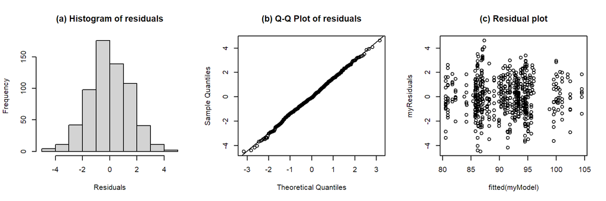

```
## Linear mixed model fit by REML. t-tests use Satterthwaite's method [
## lmerModLmerTest]
## Formula: h_f0 ~ mode + acc_phon + mode:acc_phon + fin_phon + gender +
##     (1 + acc_phon | speaker)
##    Data: m_corpus
## Control:
## lmerControl(optimizer = "optimx", calc.derivs = FALSE, optCtrl = list(method = "nlminb",
##     starttests = FALSE, kkt = FALSE))
##
## REML criterion at convergence: 2406.7
##
## Scaled residuals:
##      Min       1Q   Median       3Q      Max
## -2.91772 -0.64392 -0.05215  0.66656  3.01423
##
## Random effects:
##  Groups   Name           Variance Std.Dev. Corr
##  speaker  (Intercept)    10.272   3.205
##           acc_phon^[L*]H  2.342   1.530     0.00
##           acc_phonL*^[H]  2.508   1.584     0.33  0.00
##           acc_phon^[L*H]  4.162   2.040    -0.05  0.00  0.10
##  Residual                 2.342   1.530
## Number of obs: 632, groups:  speaker, 11
##
## Fixed effects:
##                        Estimate Std. Error       df t value Pr(>|t|)
## (Intercept)             92.5245     1.3067   9.2685  70.806 5.46e-14 ***
## modeMWH                  0.3855     0.1716 593.6215   2.247 0.025024 *
## modeMYN                  1.1599     0.1909 594.5483   6.077 2.19e-09 ***
## modeMDQ                  1.5638     0.2774 597.5371   5.638 2.66e-08 ***
## acc_phon^[L*]H           0.4560     1.8133  32.0703   0.251 0.803076
## acc_phonL*^[H]           5.2555     0.7507   5.6437   7.001 0.000552 ***
## acc_phon^[L*H]           5.0780     0.7192  11.9027   7.060 1.38e-05 ***
## fin_phonL%              -0.4196     0.2347 607.7696  -1.788 0.074350 .
## genderM                 -7.1215     1.9156   9.2536  -3.718 0.004563 **
## modeMYN:acc_phon^[L*]H  -0.4261     1.2816 593.7135  -0.332 0.739633
## modeMWH:acc_phonL*^[H]  -2.1807     1.6858 575.5273  -1.294 0.196339
## modeMYN:acc_phonL*^[H]  -2.5302     0.8490 580.9383  -2.980 0.003002 **
## modeMYN:acc_phon^[L*H]  -1.5160     0.4608 602.4485  -3.290 0.001062 **
## ---
```

[output cut: 26 more lines]

```
## ---
## Signif. codes:  0 '***' 0.001 '**' 0.01 '*' 0.05 '.' 0.1 ' ' 1
##
## Backward reduced fixed-effect table:
## Degrees of freedom method: Satterthwaite
##
##               Eliminated Sum Sq Mean Sq NumDF  DenDF F value   Pr(>F)
## fin_phon               1  7.484   7.484     1 607.77  3.1953 0.074350 .
## gender                 0 32.220  32.220     1   9.19 13.7208 0.004718 **
## mode:acc_phon          0 41.621  10.405     4 593.61  4.4310 0.001549 **
## ---
## Signif. codes:  0 '***' 0.001 '**' 0.01 '*' 0.05 '.' 0.1 ' ' 1
##
## Model found:
## h_f0 ~ mode + acc_phon + gender + (1 + acc_phon | speaker) + mode:acc_phon
```

- Model works.

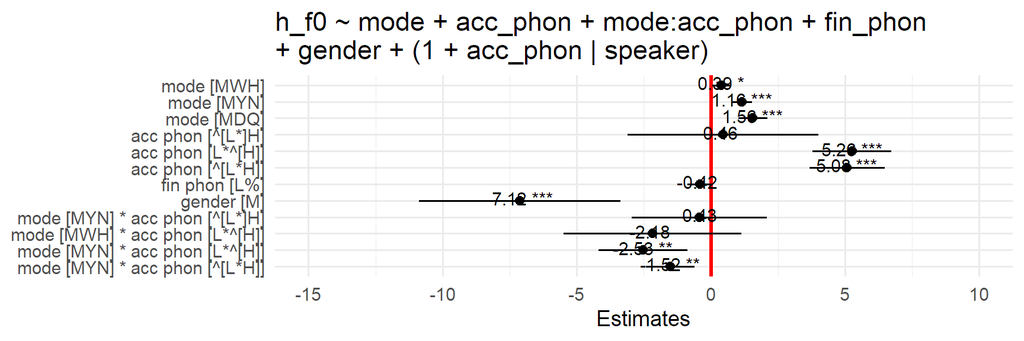

Intercept and slopes of fixed effects: h_f0 ~ mode + acc_phon + mode:acc_phon + fin_phon + gender + (1 + acc_phon | speaker)

| term | estimate | std.error | 2.5% CI | 97.5% CI | t.value | df | p.value | p.adj. (bf=8) | signif. |
| --- | --- | --- | --- | --- | --- | --- | --- | --- | --- |
| (Intercept) | 92.525 | 1.307 | 89.963 | 95.086 | 70.806 | 9.27 | 5.4620e-14 | 3.82e-13 | p<0.001 |
| modeMWH | 0.385 | 0.172 | 0.049 | 0.722 | 2.247 | 593.62 | 0.025 | 0.1752 |  |
| modeMYN | 1.160 | 0.191 | 0.786 | 1.534 | 6.077 | 594.55 | 2.1890e-09 | 1.53e-08 | p<0.001 |
| modeMDQ | 1.564 | 0.277 | 1.020 | 2.107 | 5.638 | 597.54 | 2.6620e-08 | 1.86e-07 | p<0.001 |
| acc_phon^[L*]H | 0.456 | 1.813 | -3.098 | 4.010 | 0.251 | 32.07 | 0.8031 | 0.9999 |  |
| acc_phonL*^[H] | 5.256 | 0.751 | 3.784 | 6.727 | 7.001 | 5.64 | 5.5186e-04 | 0.0039 | p<0.01 |
| acc_phon^[L*H] | 5.078 | 0.719 | 3.668 | 6.488 | 7.060 | 11.90 | 1.3778e-05 | 9.64e-05 | p<0.001 |
| fin_phonL% | -0.420 | 0.235 | -0.880 | 0.040 | -1.788 | 607.77 | 0.0743 | NA |  |
| genderM | -7.121 | 1.916 | -10.876 | -3.367 | -3.718 | 9.25 | 0.0046 | NA | p<0.01 |
| modeMYN:acc_phon^[L*]H | -0.426 | 1.282 | -2.938 | 2.086 | -0.332 | 593.71 | 0.7396 | 0.9999 |  |
| modeMWH:acc_phonL*^[H] | -2.181 | 1.686 | -5.485 | 1.123 | -1.294 | 575.53 | 0.1963 | 0.9999 |  |
| modeMYN:acc_phonL*^[H] | -2.530 | 0.849 | -4.194 | -0.866 | -2.980 | 580.94 | 0.003 | 0.021 | p<0.05 |
| modeMYN:acc_phon^[L*H] | -1.516 | 0.461 | -2.419 | -0.613 | -3.290 | 602.45 | 0.0011 | 0.0074 | p<0.01 |

Conditional and marginal R<sup>2</sup> of model

| R2_conditional | R2_marginal | optional |
| --- | --- | --- |
| 0.92 | 0.55 | FALSE |

b0 for h_f0 ~ mode + acc_phon + mode:acc_phon + fin_phon + gender + (1 + acc_phon | speaker)

| intercept | estimate | std.error | 2.5% CI | 97.5% CI | t.value | df | p.value | p.adj. (bf=8) | signif. |
| --- | --- | --- | --- | --- | --- | --- | --- | --- | --- |
| modeMDC | 92.525 | 1.307 | 89.963 | 95.086 | 70.806 | 9.27 | 5.4620e-14 | 4.37e-13 | p<0.001 |
| modeMWH | 92.910 | 1.307 | 90.349 | 95.471 | 71.098 | 9.27 | 5.2182e-14 | 4.17e-13 | p<0.001 |
| modeMYN | 93.684 | 1.308 | 91.120 | 96.249 | 71.611 | 9.31 | 4.3660e-14 | 3.49e-13 | p<0.001 |
| modeMDQ | 94.088 | 1.323 | 91.495 | 96.682 | 71.100 | 9.75 | 1.4270e-14 | 1.14e-13 | p<0.001 |
| acc_phonL*H | 92.525 | 1.307 | 89.963 | 95.086 | 70.806 | 9.27 | 5.4620e-14 | 4.37e-13 | p<0.001 |
| acc_phon^[L*]H | 93.177 | 1.865 | 89.523 | 96.832 | 49.969 | 0.00 | 0.9987 | 0.9999 |  |
| acc_phonL*^[H] | 97.780 | 1.654 | 94.538 | 101.022 | 59.112 | 9.52 | 1.5425e-13 | 1.23e-12 | p<0.001 |
| acc_phon^[L*H] | 97.602 | 1.477 | 94.709 | 100.496 | 66.104 | 11.53 | 3.1097e-16 | 2.49e-15 | p<0.001 |

b1 for h_f0 ~ mode + acc_phon + mode:acc_phon + fin_phon + gender + (1 + acc_phon | speaker)

| intercept | slope | estimate | std.error | 2.5% CI | 97.5% CI | t.value | df | p.value | p.adj. (bf=8) | signif. |
| --- | --- | --- | --- | --- | --- | --- | --- | --- | --- | --- |
| modeMDC | modeMWH | 0.385 | 0.172 | 0.049 | 0.722 | 2.247 | 593.62 | 0.025 | 0.2002 |  |
| modeMDC | modeMYN | 1.160 | 0.191 | 0.786 | 1.534 | 6.077 | 594.55 | 2.1890e-09 | 1.75e-08 | p<0.001 |
| modeMDC | modeMDQ | 1.564 | 0.277 | 1.020 | 2.107 | 5.638 | 597.54 | 2.6620e-08 | 2.13e-07 | p<0.001 |
| modeMWH | modeMYN | 0.774 | 0.192 | 0.399 | 1.150 | 4.039 | 594.83 | 6.0682e-05 | 4.85e-04 | p<0.001 |
| modeMWH | modeMDQ | 1.178 | 0.278 | 0.633 | 1.723 | 4.239 | 597.67 | 2.6004e-05 | 2.08e-04 | p<0.001 |
| modeMYN | modeMDQ | 0.404 | 0.285 | -0.154 | 0.962 | 1.419 | 596.67 | 0.1565 | 0.9999 |  |
| acc_phonL*H | acc_phon^[L*]H | 0.456 | 1.813 | -3.098 | 4.010 | 0.251 | 32.07 | 0.8031 | 0.9999 |  |
| acc_phonL*H | acc_phonL*^[H] | 5.256 | 0.751 | 3.784 | 6.727 | 7.001 | 5.64 | 5.5186e-04 | 0.0044 | p<0.01 |
| acc_phonL*H | acc_phon^[L*H] | 5.078 | 0.719 | 3.668 | 6.488 | 7.060 | 11.90 | 1.3778e-05 | 1.10e-04 | p<0.001 |
| acc_phon^[L*]H | acc_phonL*^[H] | 4.602 | 1.493 | 1.675 | 7.529 | 3.082 | 0.00 | 0.9995 | 0.9999 |  |
| acc_phon^[L*]H | acc_phon^[L*H] | 4.425 | 1.394 | 1.692 | 7.157 | 3.174 | 0.00 | 0.9996 | 0.9999 |  |
| acc_phonL*^[H] | acc_phon^[L*H] | -0.178 | 0.947 | -2.033 | 1.678 | -0.188 | 7.83 | 0.856 | 0.9999 |  |